# A Look At Daily Returns of the S&P 500

Rex Macey

December 6, 2015

Let’s look at daily returns of the S&P 500. Here we have daily returns on the S&P 500 from January 03, 1950 through November 23, 2015. Note that the early data effectively only has closing prices. More recent data has open/high/low and close. There are 16581 prices (and 16580 returns)

```r
head(spx)
```

```
##             Open  High   Low Close  Volume Adjusted
## 1950-01-03 16.66 16.66 16.66 16.66 1260000    16.66
## 1950-01-04 16.85 16.85 16.85 16.85 1890000    16.85
## 1950-01-05 16.93 16.93 16.93 16.93 2550000    16.93
## 1950-01-06 16.98 16.98 16.98 16.98 2010000    16.98
## 1950-01-09 17.08 17.08 17.08 17.08 2520000    17.08
## 1950-01-10 17.03 17.03 17.03 17.03 2160000    17.03
```

```r
tail(spx)
```

```
##               Open    High     Low   Close     Volume Adjusted
## 2015-11-16 2022.08 2053.22 2019.39 2053.19 3741240000  2053.19
## 2015-11-17 2053.67 2066.69 2045.90 2050.44 4427350000  2050.44
## 2015-11-18 2051.99 2085.31 2051.99 2083.58 3926390000  2083.58
## 2015-11-19 2083.70 2086.74 2078.76 2081.24 3628110000  2081.24
## 2015-11-20 2082.82 2097.06 2082.82 2089.17 3929600000  2089.17
## 2015-11-23 2089.41 2095.61 2081.39 2086.59 3587980000  2086.59
```

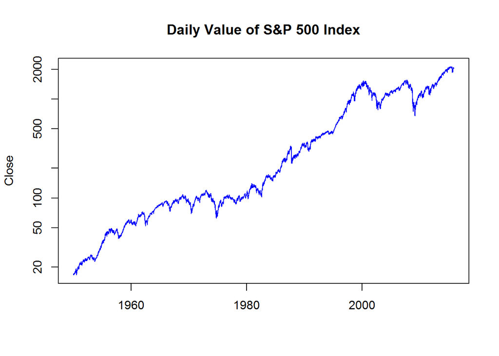

Let’s look at the distribution of daily returns. We see that the worst daily return was -20.47%. This occurred on October 19, 1987. The best return was 11.58% which occurred on October 13, 2008.

```
##      Index            daily.returns
##  Min.   :1950-01-03   Min.   :-0.2046693
##  1st Qu.:1966-06-29   1st Qu.:-0.0041141
##  Median :1983-01-10   Median : 0.0004649
##  Mean   :1982-12-26   Mean   : 0.0003385
##  3rd Qu.:1999-06-04   3rd Qu.: 0.0049771
##  Max.   :2015-11-23   Max.   : 0.1158004
##                       NA's   :1
```

A histogram shows the vast majority are clustered near 0%, but the scale indicates there are rare, large outliers. Recall there are 16580 daily returns in our dataset.

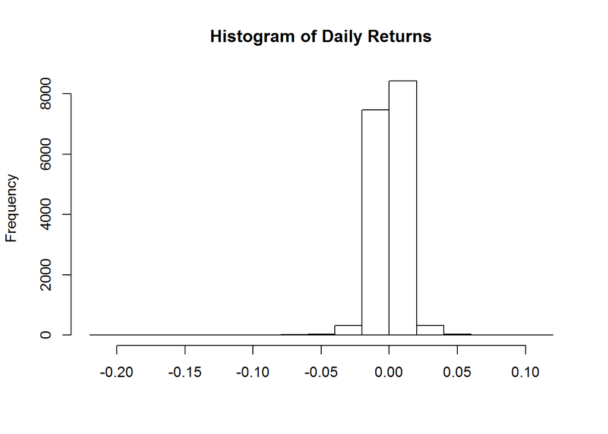

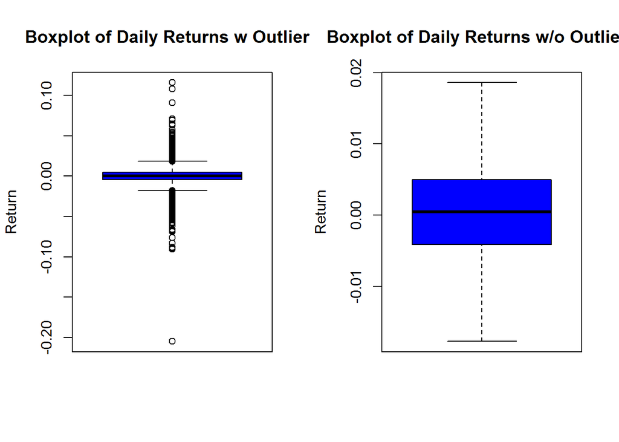

The boxplots show the dispersion as well. The blue boxes contain one-half of the observations. The whiskers (horizontal lines outside the blue) are 1.5x the width of the boxes. Points beyond the whiskers are outliers. About 5.6% of the data are outliers using this definition.

# Can we do better than average?

Again the average and median daily returns are 0.0339% and 0.0465% respectively. An investment of $1 would have grown to $125.25 ignoring taxes and dividends. The question is can we identify type of days which might be better than others?

Let’s start with an example called the turn of the month anomoly. With this we will only invest for the 3 trading days before and after the turn of the month.

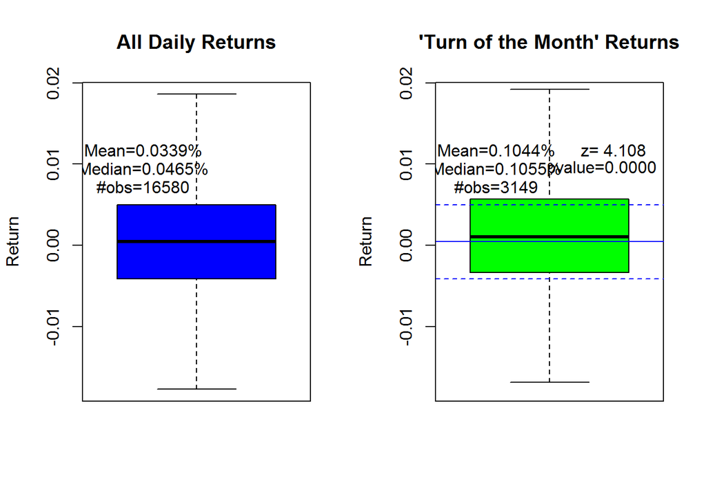

The average return around the turn of the month is significantly different from the average daily return. In fact it is about 3.1x higher. That said, these only account for 19% of the observations. If one only invested on these days, $1 would have grown into $23.12.

# Calendar Month

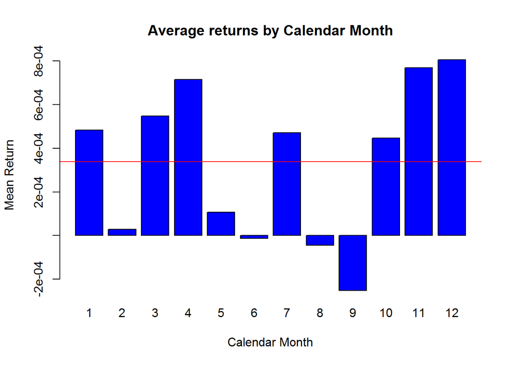

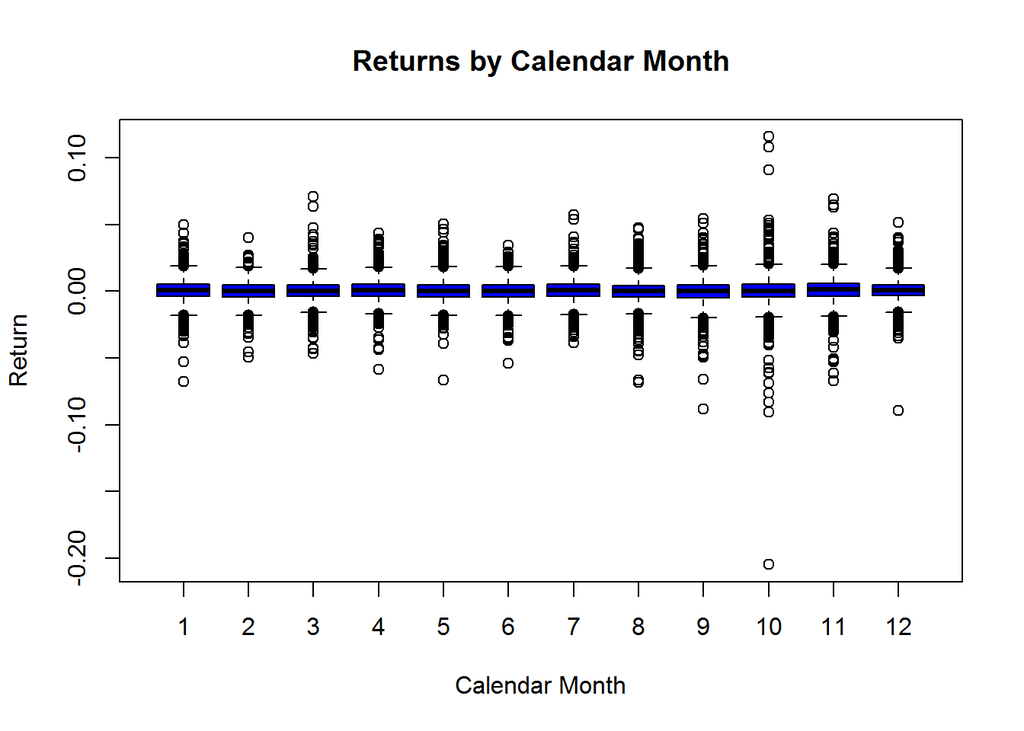

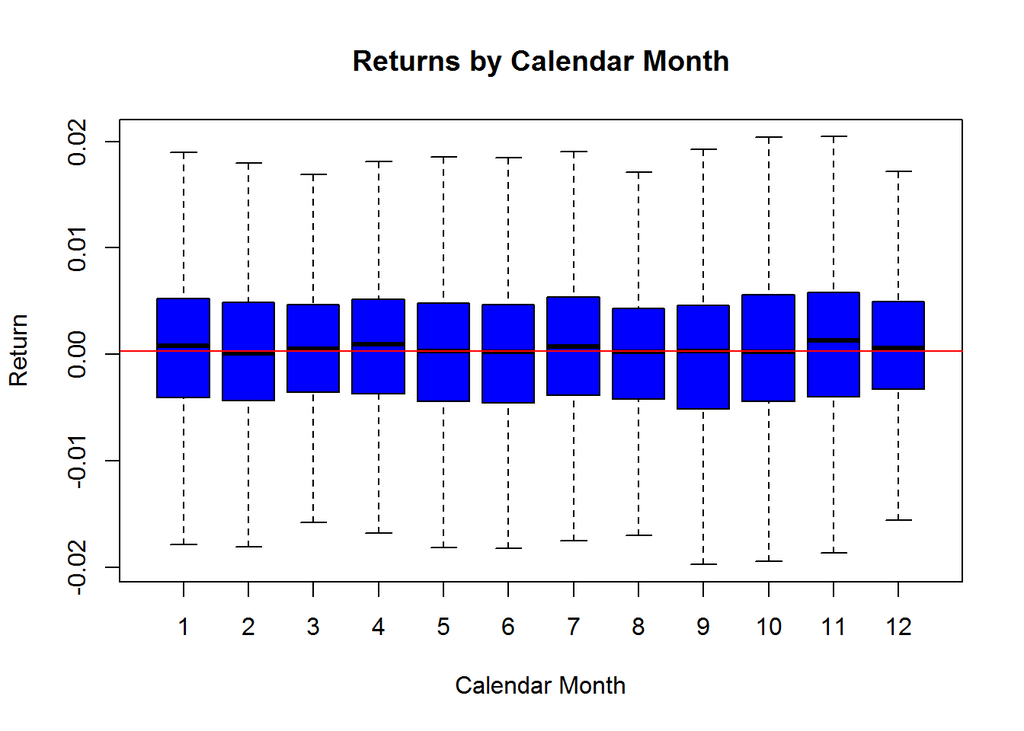

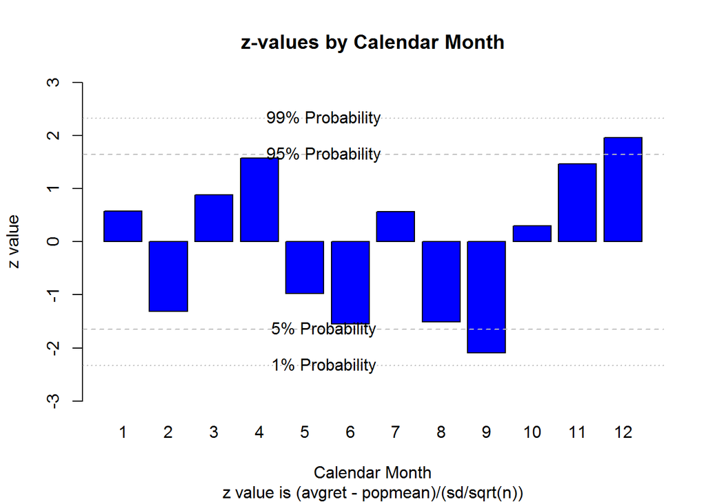

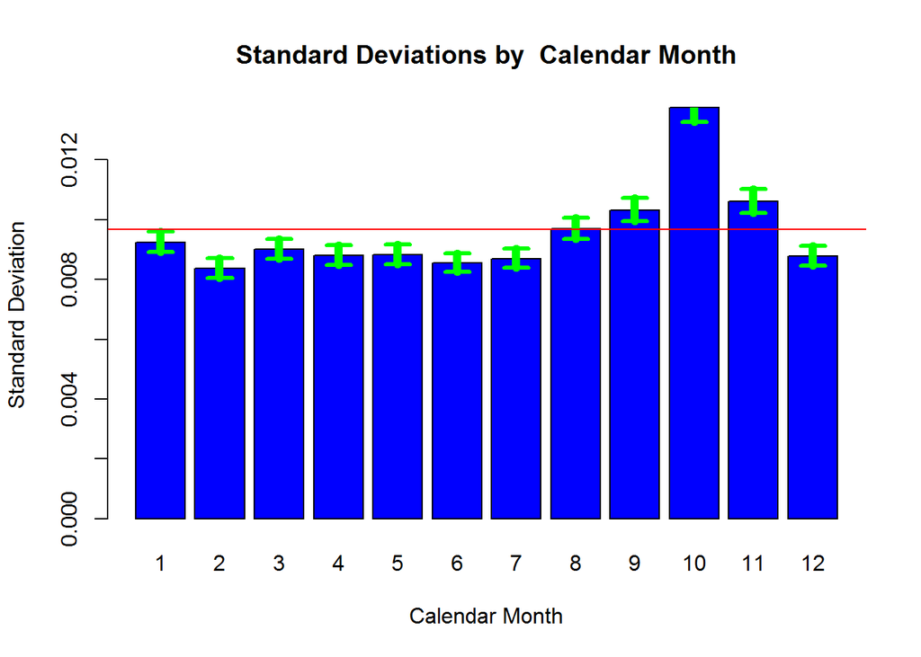

# Trading Day of Month

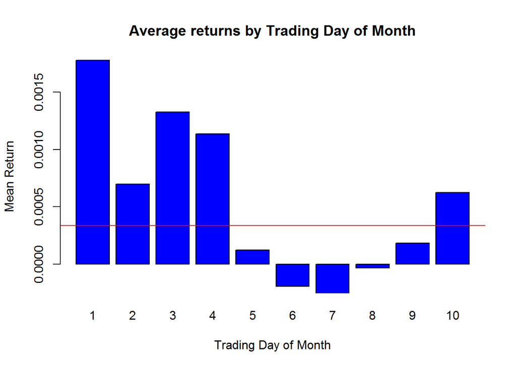

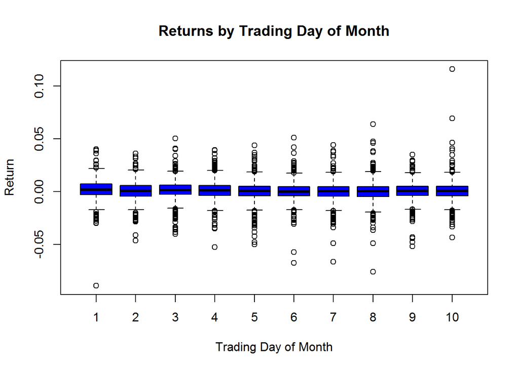

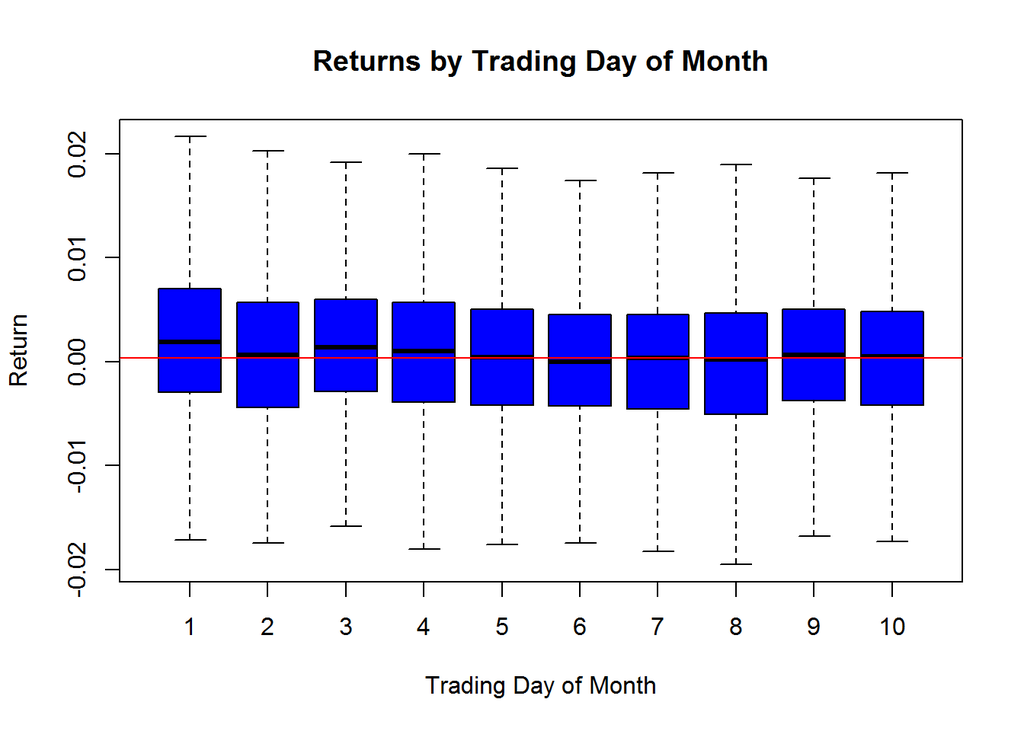

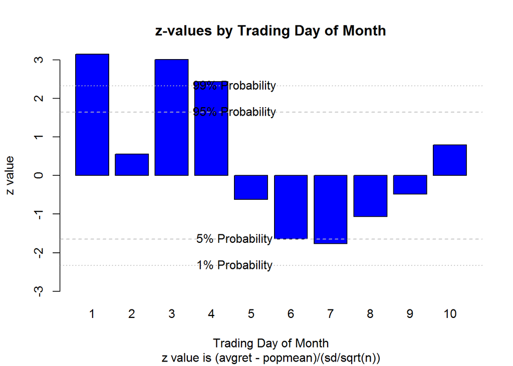

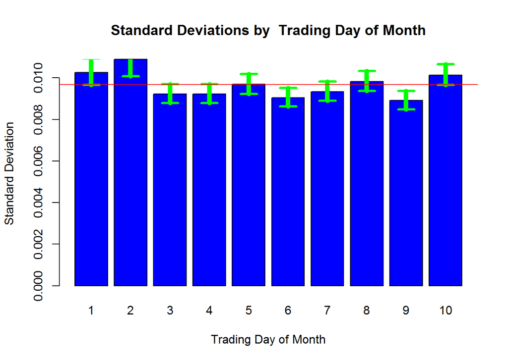

# Trading Days Left in Month

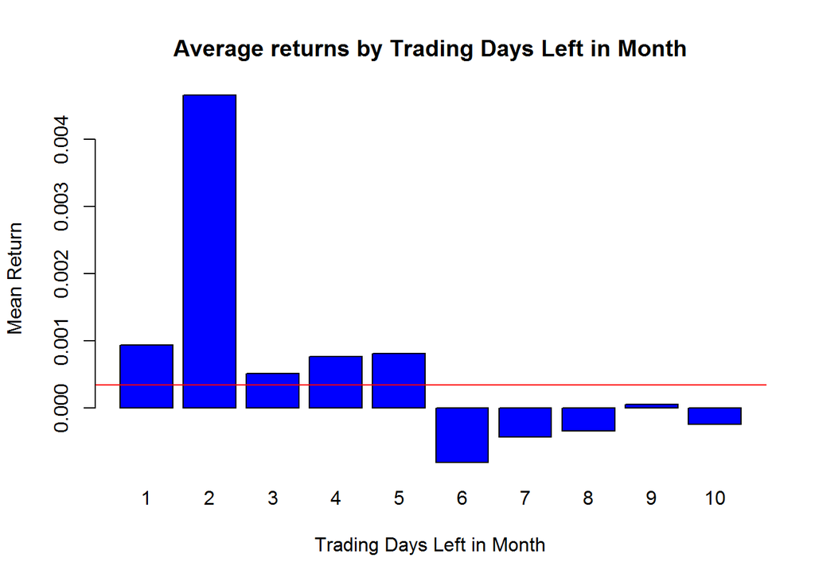

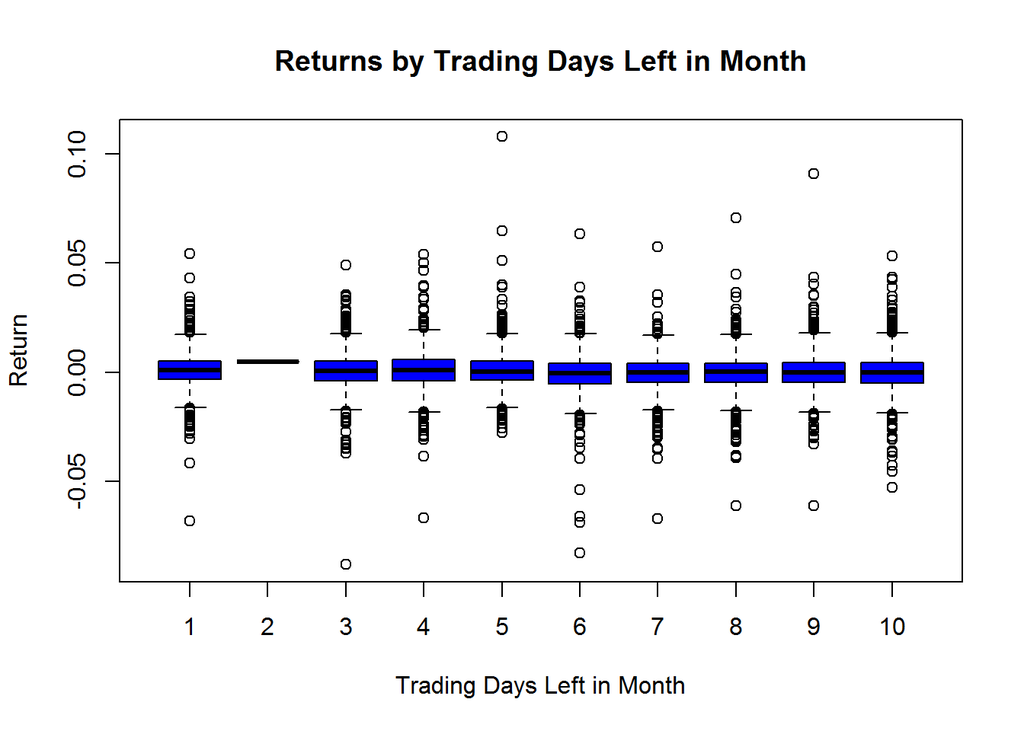

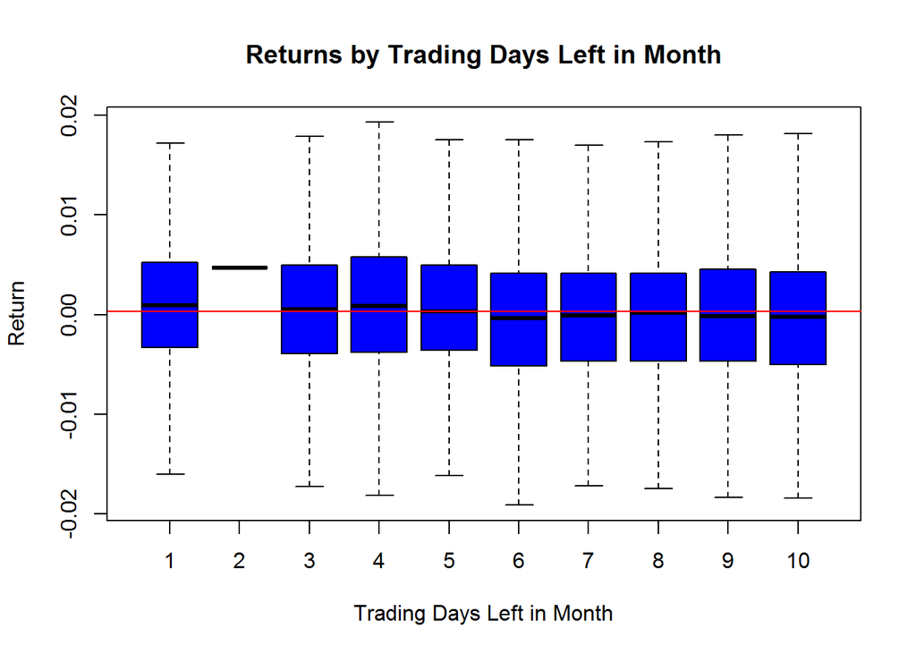

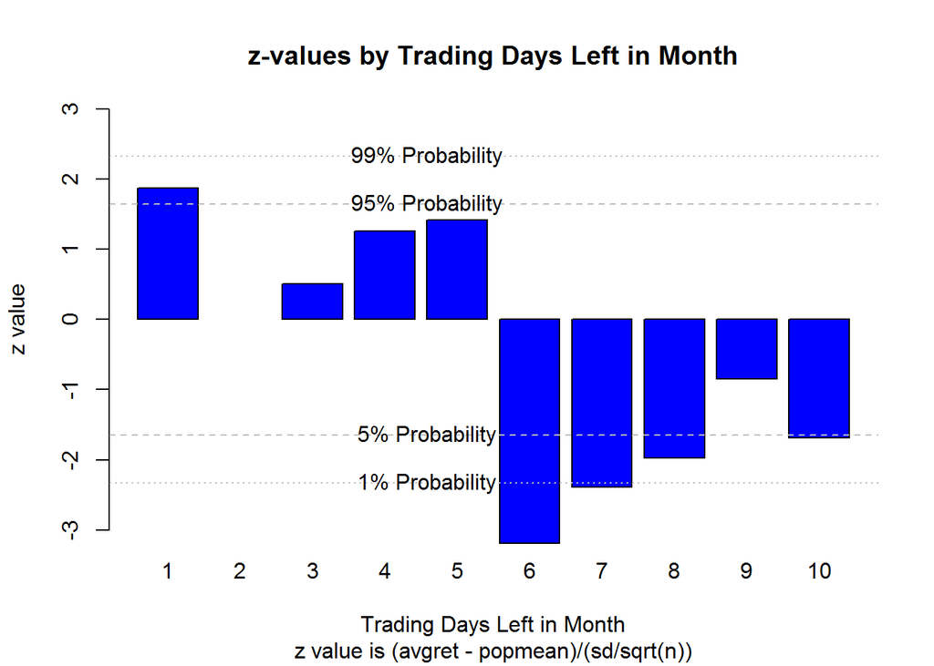

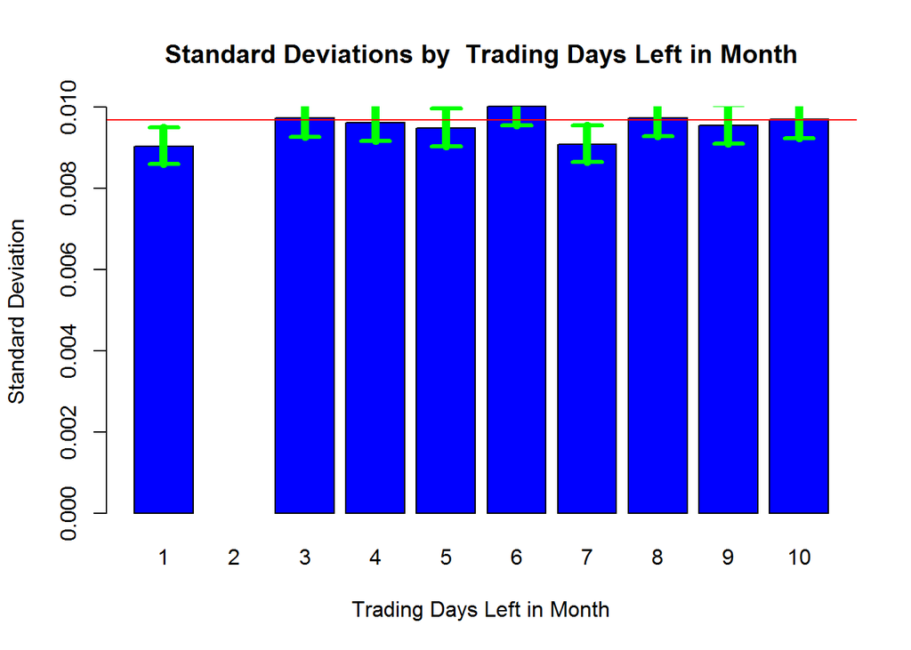

# Day of Week

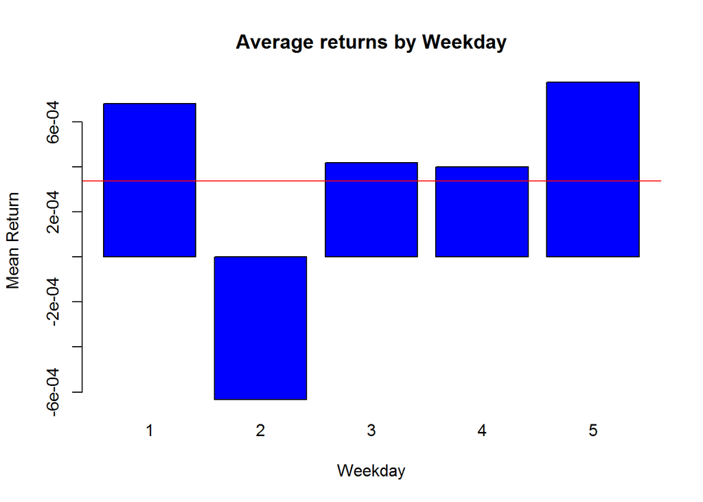

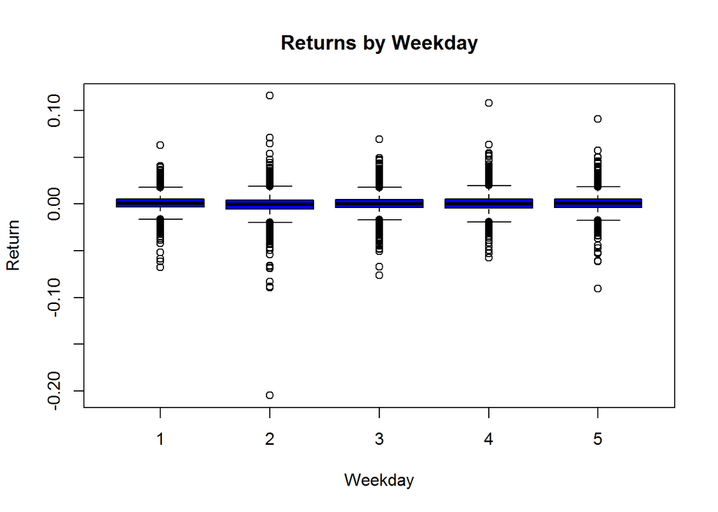

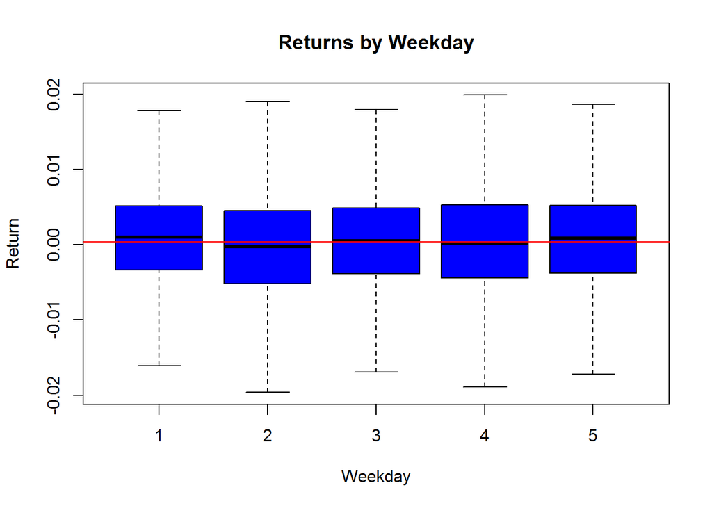

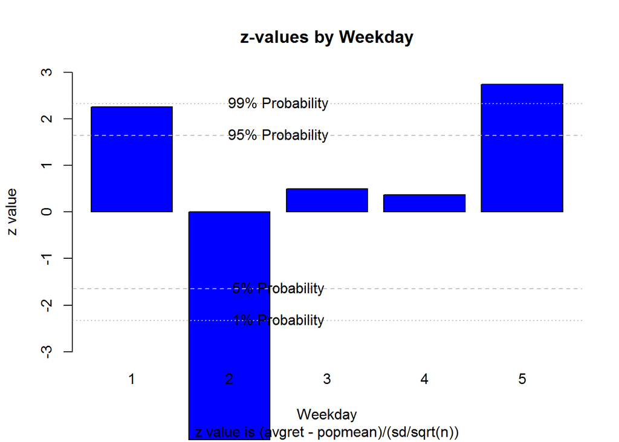

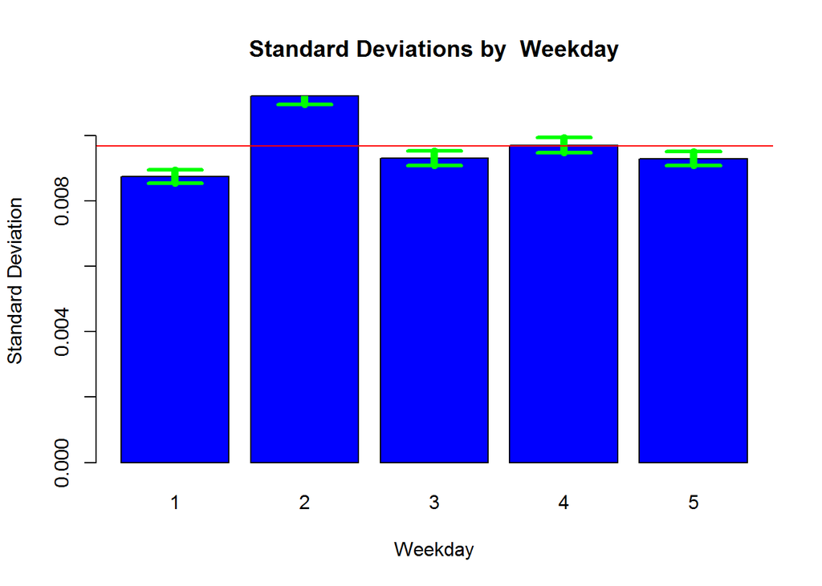

# Days from Holiday

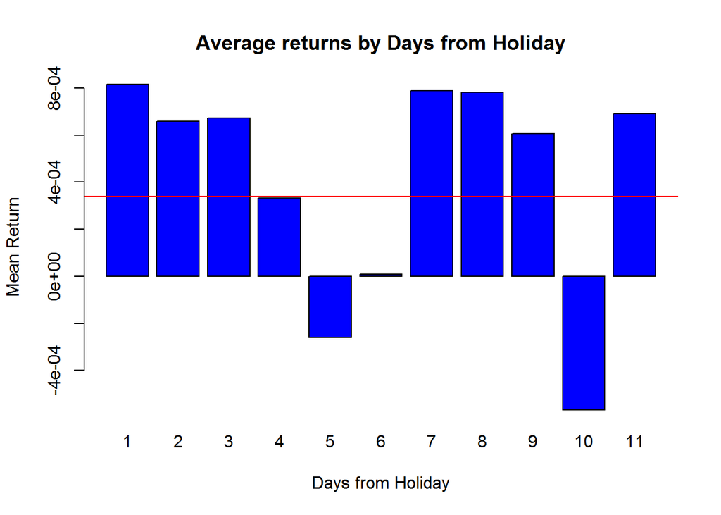

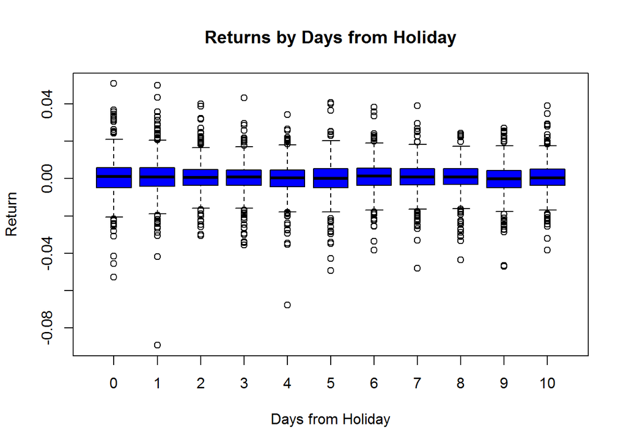

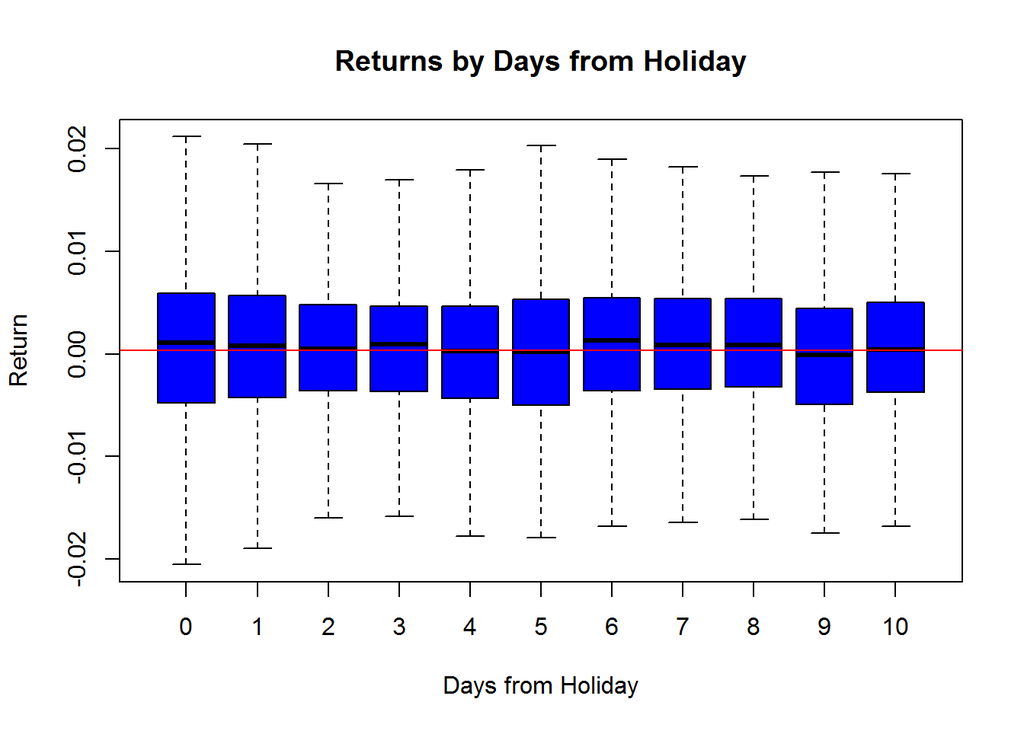

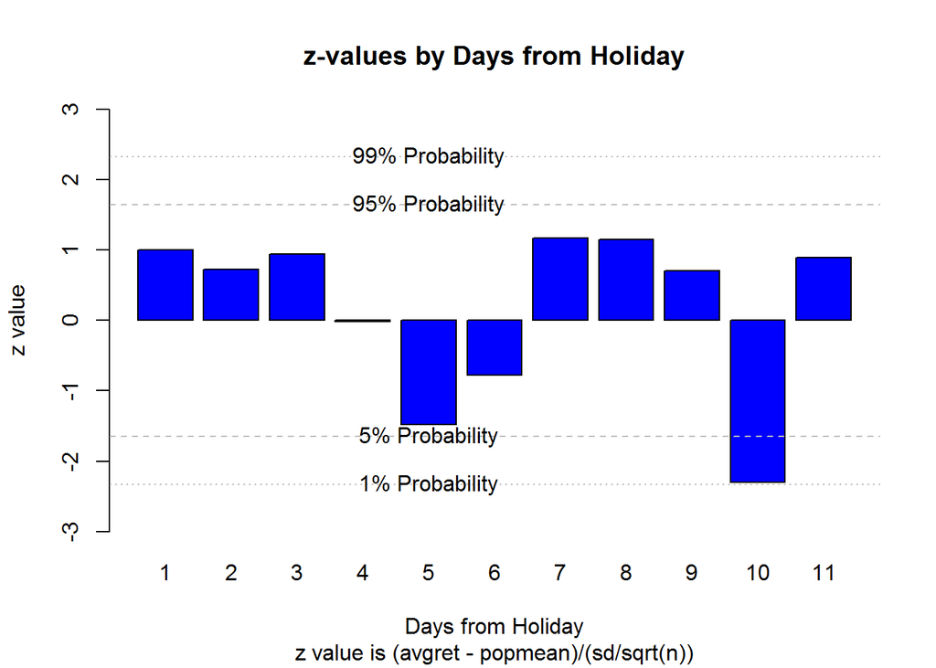

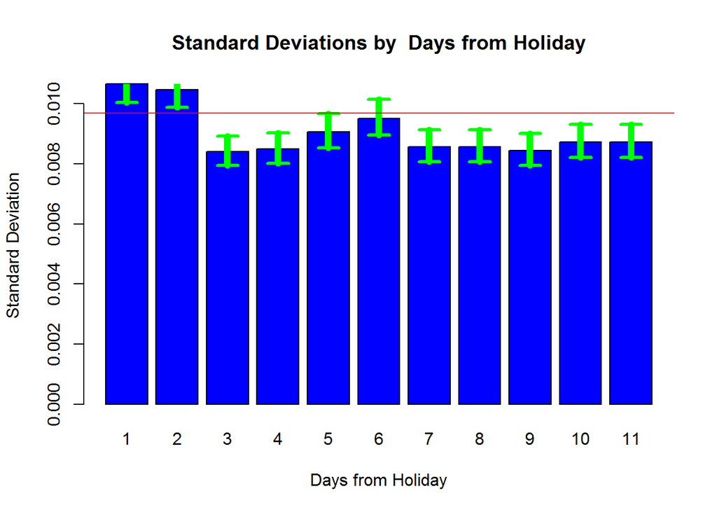